# Tools for bayesian analysis (2): `dplyr`

# 1 Data transformation

## 1.1 `tibble`

```r
library(ggplot2)
library(knitr)
library(dplyr)
df <- read.csv2("companies.csv")
head(df)
```

```
                       Company Revenue Activity     City
1     ACCIONA CONSTRUCCION SA.    1527     4121   Madrid
2          ACERINOX EUROPA SAU    1483     2410    Cadiz
3              AENA S.M.E. SA.    3755     5223   Madrid
4  AIR EUROPA LINEAS AEREAS SA    1934     5110 Baleares
5 AIRBUS DEFENCE AND SPACE SA.    2988     3030   Madrid
6           AIRBUS MILITARY SL    1681     3030   Madrid
```

```r
df <- as_tibble(df)
df
```

```
# A tibble: 100 x 4
   Company                           Revenue Activity City
   <fct>                               <int>    <int> <fct>
 1 "ACCIONA CONSTRUCCION SA."           1527     4121 Madrid
 2 "ACERINOX EUROPA SAU"                1483     2410 Cadiz
 3 "AENA S.M.E. SA."                    3755     5223 Madrid
 4 "AIR EUROPA LINEAS AEREAS SA"        1934     5110 Baleares
 5 "AIRBUS DEFENCE AND SPACE SA."       2988     3030 Madrid
 6 "AIRBUS MILITARY SL"                 1681     3030 Madrid
 7 "AIRBUS OPERATIONS SL"               1749     3030 Madrid
 8 "ALCAMPO SA"                         3294     4711 Madrid
 9 "ALUMINIO ESPA\x84OL SL"             2761     2442 Madrid
10 "ALVEAN SUGAR SOCIEDAD LIMITADA."    3831     4636 Bizkaia
# … with 90 more rows
```

## 1.2 `dplyr` verbs

`dplyr` is a package that transforms data.

`filter()` - extract cases  
`arrange()` - reorder cases  
`select()` - extract variables  
`mutate()`- create new variables  
`summarise()` - summarise variables / create cases

`group_by()` - group cases

**Common syntax**: each function take a data frame as its first argument and returns a data frame.

### 1.2.1 `filter()`

Extract rows that meet logical criteria.

```r
filter(df, City == "Barcelona")
```

```
# A tibble: 7 x 4
  Company                                       Revenue Activity City
  <fct>                                           <int>    <int> <fct>
1 "FOMENTO DE CONSTRUCCIONES Y CONTRATAS SA"       1666     3811 Barcelona
2 "NESTLE ESPA\x84A SAU"                           1925     1086 Barcelona
3 "NISSAN MOTOR IBERICA SA"                        2663     2910 Barcelona
4 "PUNTO FA SL"                                    1577     4771 Barcelona
5 "SEAT SA"                                        9552     2910 Barcelona
6 "VOLKSWAGEN GROUP ESPA\x84A DISTRIBUCION SA."    3628     4511 Barcelona
7 "VUELING AIRLINES, SA"                           2085     5110 Barcelona
```

```r
filter(df, City == "Barcelona", Revenue > 3000)
```

```
# A tibble: 2 x 4
  Company                                       Revenue Activity City
  <fct>                                           <int>    <int> <fct>
1 "SEAT SA"                                        9552     2910 Barcelona
2 "VOLKSWAGEN GROUP ESPA\x84A DISTRIBUCION SA."    3628     4511 Barcelona
```

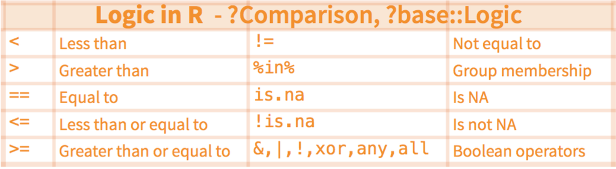

### 1.2.2 `arrange()`

Order rows from smallest to largest values.

```r
arrange(df, Revenue)
```

```
# A tibble: 100 x 4
   Company                                             Revenue Activity City
   <fct>                                                 <int>    <int> <fct>
 1 "SAGANE SA"                                            1450     3523 Madrid
 2 "TECH DATA ESPA\x84A SL"                               1450     4651 Madrid
 3 "PRIMARK TIENDAS SLU"                                  1472     4751 Madrid
 4 "ACERINOX EUROPA SAU"                                  1483     2410 Cadiz
 5 "IBERDROLA COMERCIALIZACION DE ULTIMO RECURSO SOCI…    1516     3514 Bizkaia
 6 "ACCIONA CONSTRUCCION SA."                             1527     4121 Madrid
 7 "TELEFONICA AUDIOVISUAL DIGITAL SL."                   1556     6020 Madrid
 8 "PUNTO FA SL"                                          1577     4771 Barcelo…
 9 "IBERDROLA ESPA\x84A SOCIEDAD ANONIMA."                1611     6420 Bizkaia
10 "EDP ESPA\x84A SA."                                    1616     3516 Asturias
# … with 90 more rows
```

`desc()` changes ordering to largest to smallest.

```r
arrange(df, desc(Revenue))
```

```
# A tibble: 100 x 4
   Company                                         Revenue Activity City
   <fct>                                             <int>    <int> <fct>
 1 "MERCADONA SA"                                    21012     4711 "Valencia"
 2 "REPSOL PETROLEO SA"                              19179     1920 "Madrid"
 3 "COMPA\x84IA ESPA\x84OLA DE PETROLEOS SAU"        16154     1920 "Madrid"
 4 "REPSOL COMERCIAL DE PRODUCTOS PETROLIFEROS SA"   14053     4671 "Madrid"
 5 "CEPSA TRADING SAU"                               13513     4671 "Madrid"
 6 "ENDESA ENERGIA SAU"                              12582     3514 "Madrid"
 7 "EL CORTE INGLES SA"                              11484     4719 "Madrid"
 8 "INDUSTRIA DE DISE\x84O TEXTIL SA"                10242     4642 "Coru\x96a"
 9 "SEAT SA"                                          9552     2910 "Barcelona"
10 "FORD ESPA\x84A SL"                                9150     2910 "Madrid"
# … with 90 more rows
```

### 1.2.3 `select()`

Extract columns by name.

```r
select(df, Company, City)
```

```
# A tibble: 100 x 2
   Company                           City
   <fct>                             <fct>
 1 "ACCIONA CONSTRUCCION SA."        Madrid
 2 "ACERINOX EUROPA SAU"             Cadiz
 3 "AENA S.M.E. SA."                 Madrid
 4 "AIR EUROPA LINEAS AEREAS SA"     Baleares
 5 "AIRBUS DEFENCE AND SPACE SA."    Madrid
 6 "AIRBUS MILITARY SL"              Madrid
 7 "AIRBUS OPERATIONS SL"            Madrid
 8 "ALCAMPO SA"                      Madrid
 9 "ALUMINIO ESPA\x84OL SL"          Madrid
10 "ALVEAN SUGAR SOCIEDAD LIMITADA." Bizkaia
# … with 90 more rows
```

`:` Select range of columns

```r
select(df, Company:Activity)
```

```
# A tibble: 100 x 3
   Company                           Revenue Activity
   <fct>                               <int>    <int>
 1 "ACCIONA CONSTRUCCION SA."           1527     4121
 2 "ACERINOX EUROPA SAU"                1483     2410
 3 "AENA S.M.E. SA."                    3755     5223
 4 "AIR EUROPA LINEAS AEREAS SA"        1934     5110
 5 "AIRBUS DEFENCE AND SPACE SA."       2988     3030
 6 "AIRBUS MILITARY SL"                 1681     3030
 7 "AIRBUS OPERATIONS SL"               1749     3030
 8 "ALCAMPO SA"                         3294     4711
 9 "ALUMINIO ESPA\x84OL SL"             2761     2442
10 "ALVEAN SUGAR SOCIEDAD LIMITADA."    3831     4636
# … with 90 more rows
```

`-` Select every column but

```r
select(df, -c(Company, City))
```

```
# A tibble: 100 x 2
   Revenue Activity
     <int>    <int>
 1    1527     4121
 2    1483     2410
 3    3755     5223
 4    1934     5110
 5    2988     3030
 6    1681     3030
 7    1749     3030
 8    3294     4711
 9    2761     2442
10    3831     4636
# … with 90 more rows
```

`starts_with()` Select columns that start with…

```r
select(df, starts_with("C"))
```

```
# A tibble: 100 x 2
   Company                           City
   <fct>                             <fct>
 1 "ACCIONA CONSTRUCCION SA."        Madrid
 2 "ACERINOX EUROPA SAU"             Cadiz
 3 "AENA S.M.E. SA."                 Madrid
 4 "AIR EUROPA LINEAS AEREAS SA"     Baleares
 5 "AIRBUS DEFENCE AND SPACE SA."    Madrid
 6 "AIRBUS MILITARY SL"              Madrid
 7 "AIRBUS OPERATIONS SL"            Madrid
 8 "ALCAMPO SA"                      Madrid
 9 "ALUMINIO ESPA\x84OL SL"          Madrid
10 "ALVEAN SUGAR SOCIEDAD LIMITADA." Bizkaia
# … with 90 more rows
```

`ends_with()` Select columns that end with…

```r
select(df, ends_with("y"))
```

```
# A tibble: 100 x 3
   Company                           Activity City
   <fct>                                <int> <fct>
 1 "ACCIONA CONSTRUCCION SA."            4121 Madrid
 2 "ACERINOX EUROPA SAU"                 2410 Cadiz
 3 "AENA S.M.E. SA."                     5223 Madrid
 4 "AIR EUROPA LINEAS AEREAS SA"         5110 Baleares
 5 "AIRBUS DEFENCE AND SPACE SA."        3030 Madrid
 6 "AIRBUS MILITARY SL"                  3030 Madrid
 7 "AIRBUS OPERATIONS SL"                3030 Madrid
 8 "ALCAMPO SA"                          4711 Madrid
 9 "ALUMINIO ESPA\x84OL SL"              2442 Madrid
10 "ALVEAN SUGAR SOCIEDAD LIMITADA."     4636 Bizkaia
# … with 90 more rows
```

`contains()` - Select columns whose names contain…

```r
select(df, contains("it"))
```

```
# A tibble: 100 x 2
   Activity City
      <int> <fct>
 1     4121 Madrid
 2     2410 Cadiz
 3     5223 Madrid
 4     5110 Baleares
 5     3030 Madrid
 6     3030 Madrid
 7     3030 Madrid
 8     4711 Madrid
 9     2442 Madrid
10     4636 Bizkaia
# … with 90 more rows
```

### 1.2.4 `mutate()`

Create new columns.

```r
mutate(df,
  Rev_per_month = Revenue / 12,
  Rev_per_week = Rev_per_month / 4)
```

```
# A tibble: 100 x 6
   Company                   Revenue Activity City    Rev_per_month Rev_per_week
   <fct>                       <int>    <int> <fct>           <dbl>        <dbl>
 1 "ACCIONA CONSTRUCCION SA…    1527     4121 Madrid           127.         31.8
 2 "ACERINOX EUROPA SAU"        1483     2410 Cadiz            124.         30.9
 3 "AENA S.M.E. SA."            3755     5223 Madrid           313.         78.2
 4 "AIR EUROPA LINEAS AEREA…    1934     5110 Balear…          161.         40.3
 5 "AIRBUS DEFENCE AND SPAC…    2988     3030 Madrid           249          62.2
 6 "AIRBUS MILITARY SL"         1681     3030 Madrid           140.         35.0
 7 "AIRBUS OPERATIONS SL"       1749     3030 Madrid           146.         36.4
 8 "ALCAMPO SA"                 3294     4711 Madrid           274.         68.6
 9 "ALUMINIO ESPA\x84OL SL"     2761     2442 Madrid           230.         57.5
10 "ALVEAN SUGAR SOCIEDAD L…    3831     4636 Bizkaia          319.         79.8
# … with 90 more rows
```

`transmute()`: create new columns. Drop the old.

```r
transmute(df, Rev_per_month = Revenue / 12)
```

```
# A tibble: 100 x 1
   Rev_per_month
           <dbl>
 1          127.
 2          124.
 3          313.
 4          161.
 5          249
 6          140.
 7          146.
 8          274.
 9          230.
10          319.
# … with 90 more rows
```

### 1.2.5 `summarise()`

Compute table of summaries.

Take a vector as input. Return a single value as output.

```r
summarise(df, n = n(),
  Rev_total = sum(Revenue),
  Rev_mean = mean(Revenue),
  Tot_act = n_distinct(Activity))
```

```
# A tibble: 1 x 4
      n Rev_total Rev_mean Tot_act
  <int>     <int>    <dbl>   <int>
1   100    414449    4144.      55
```

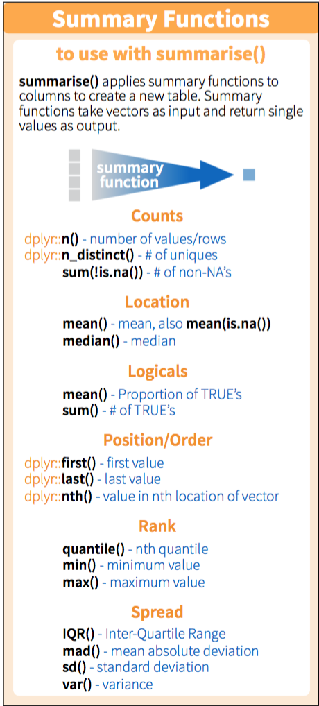

## 1.3 `%>%` operator

The pipe operator `%>%` passes result on le into first argument of function on right.

```r
df %>%
    summarise(n = n(),
      Rev_total = sum(Revenue),
      Rev_mean = mean(Revenue),
      Tot_act = n_distinct(Activity))
```

```
# A tibble: 1 x 4
      n Rev_total Rev_mean Tot_act
  <int>     <int>    <dbl>   <int>
1   100    414449    4144.      55
```

Shortcut to type `%>%`:

Cmd + Shift + M (Mac)

Ctrl + Shift + M (Windows)

### 1.3.1 `group_by()`

Groups cases by common values.

```r
df %>%
    group_by(City) %>%
    summarise(n = n(),
      Rev_total = sum(Revenue),
      Rev_mean = mean(Revenue),
      Tot_act = n_distinct(Activity))
```

```
# A tibble: 18 x 5
   City             n Rev_total Rev_mean Tot_act
   <fct>        <int>     <int>    <dbl>   <int>
 1 "Asturias"       2      5020    2510        2
 2 "Baleares"       2      3668    1834        2
 3 "Barcelona"      7     23096    3299.       6
 4 "Bizkaia"        9     32758    3640.       6
 5 "Cadiz"          1      1483    1483        1
 6 "Coru\x96a"      2     12137    6068.       2
 7 "Granada"        1      2238    2238        1
 8 "Huelva"         1      1789    1789        1
 9 "Lerida"         1      1674    1674        1
10 "Madrid"        63    274168    4352.      44
11 "Malaga"         1      2175    2175        1
12 "Navarra"        1      2525    2525        1
13 "Pontevedra"     1      5047    5047        1
14 "Sevilla"        1      4530    4530        1
15 "Tenerife"       1      1736    1736        1
16 "Valencia"       2     23365   11682.       1
17 "Valladolid"     2     10810    5405        2
18 "Zaragoza"       2      6230    3115        2
```

> Exercise:
> - How many companies are there in each city with a `revenue> 3000` and how many with a `revenue <3000`?

```r
df %>%
    mutate(Volume = ifelse(Revenue > 3000, ">3000", "<3000")) %>%
    group_by(City, Volume) %>%
    summarise(n_3000 = n())
```

```
# A tibble: 26 x 3
# Groups:   City [18]
   City        Volume n_3000
   <fct>       <chr>   <int>
 1 "Asturias"  <3000       1
 2 "Asturias"  >3000       1
 3 "Baleares"  <3000       2
 4 "Barcelona" <3000       5
 5 "Barcelona" >3000       2
 6 "Bizkaia"   <3000       5
 7 "Bizkaia"   >3000       4
 8 "Cadiz"     <3000       1
 9 "Coru\x96a" <3000       1
10 "Coru\x96a" >3000       1
# … with 16 more rows
```

# 2 Exercises

## 2.1 Exercise 1

> - Simulate a sample of size 10,000 of the following distributions: $N (\mu = 5, \sigma = 3)$ and $N(\mu = 7, \sigma = 1)$. Save the simulations in a *tibble*.
> - Calculate the product of the previous samples (you can use the `mutate()` function from the `dplyr` library).
> - Make a figure that compares its density functions (`geom_density()`). To do this, make a first graphic using `facet` and a second one overlaying the densities (you can use the parameter `alpha` to control the transparency of the densities).

## 2.2 Exercise 2

> Use `geom_function()` to graphically represent:  
> - a Normal standard distribution,  
> - a $\mathcal{N}(\mu = 7, \sigma=1)$ distribution and  
> - a $Beta(a, b)$ distribution. Use several values of the $a$ and $b$ parameters and analyze how the density changes.

# 3 References

- **R for Data Science** by Hadley Wickham and Garrett Grolemund: [book](http://shop.oreilly.com/product/0636920034407.do), [URL](https://r4ds.had.co.nz)
- [Hadley Wickham’s `dplyr` tutorial at USER! 2014](http://datascience.la/hadley-wickhams-dplyr-tutorial-at-user-2014-part-1/)
- **Datacamp**:
  - Data Visualization with ggplot [(Part 1)](https://www.datacamp.com/courses/data-visualization-with-ggplot2-1), [(Part 2)](https://www.datacamp.com/courses/data-visualization-with-ggplot2-2), [(Part 3)](https://www.datacamp.com/courses/data-visualization-with-ggplot2-3)
  - [Data Manipulation in R with dplyr](https://www.datacamp.com/courses/dplyr-data-manipulation-r-tutorial)